Realizado por:

*Sergio Ranz Casado*  
*Marcos Medina Cogolludo*

# 01. LOAD DATA y PRIMERA EXPLORACIÓN DE DATOS.

*DATASET:*

Este dataset esta compuesto de la base de datos de accidentes en Canadá. Podeis encontrar los datos [`aquí.`](https://www.kaggle.com/tbsteal/canadian-car-accidents-19942014?select=drivingLegend.pdf)

Podeis ver mas sobre estas variables en nuestro [diccionario de variables.](http://localhost:8888/notebooks/Desktop/CUNEF/Practica%20Machine%20Learning/project_template/notebooks/0.0.Diccionario_Variables.ipynb)

*CONTENIDO DEL NOTEBOOK:*

En este primer notebook vamos a cargar el dataset, analizaremos la distribución de los datos, los valores anomalos y por ultimo concluiremos como tratarlo en el preprocesamiento de la manera mas optima:

Contenido del Notebook:

- Carga de datos desde parquet, lo guardamos en csv.
- Analisis de cada una de las variables.
- Analisis valores extraños (Q,QQ,N,NN,U,UU,X,XX)
- Vemos la distribución de las variables.
- Analizamos la variable objetivo C_Sev
- Analizamos la correlacción de las variables continuas.
- Conclusiones.

```python
import pandas as pd
import pyarrow.csv as pv
import pyarrow.parquet as pq
import seaborn as sns
import numpy as np
from matplotlib import pyplot as plt
from sklearn import preprocessing
import pandas as pd
import pyarrow.csv as pv
import pyarrow.parquet as pq
```

```python
import warnings
warnings.filterwarnings('ignore')
```

```python
def plot_feature(df, col_name, target):
    """
    Visualize a variable with and without faceting on the loan status.
    - df dataframe
    - col_name is the variable name in the dataframe
    - full_name is the full variable name
    - continuous is True if the variable is continuous, False otherwise
    """
    f, (ax1, ax2) = plt.subplots(nrows=1, ncols=2, figsize=(18,5), dpi=90)

    df_n = df.groupby([target, col_name]).size().reset_index()
    df_n = df_n.rename(columns={0:"conteo"})
    df_n["porcentajes"] = df_n['conteo'] / df_n.groupby(target)['conteo'].transform('sum') * 100

    sns.countplot(df[col_name], order=sorted(df[col_name].unique()), color='#5975A4', saturation=1, ax=ax1)
    ax1.set_xlabel(col_name)
    ax1.set_ylabel('Count')
    plt.xticks(rotation = 90)


    sns.barplot(data=df_n, y="porcentajes", x=col_name, hue=target, ax=ax2)
    ax2.set_xlabel(col_name)
    ax2.set_ylabel('Distribución')
    plt.xticks(rotation = 90)
    plt.tight_layout()


def get_corr_matrix(dataset = None, metodo='pearson', size_figure=[10,8]):
    # Para obtener la correlación de Spearman, sólo cambiar el metodo por 'spearman'

    if dataset is None:
        print(u'\nHace falta pasar argumentos a la función')
        return 1
    sns.set(style="white")
    # Compute the correlation matrix
    corr = dataset.corr(method=metodo)
    # Set self-correlation to zero to avoid distraction
    for i in range(corr.shape[0]):
        corr.iloc[i, i] = 0
    # Set up the matplotlib figure
    f, ax = plt.subplots(figsize=size_figure)
    # Draw the heatmap with the mask and correct aspect ratio
    sns.heatmap(corr, center=0,
                square=True, linewidths=.5,  cmap ='viridis' ) #cbar_kws={"shrink": .5}
    plt.show()
```

```python
table = pv.read_csv('../data/NCDB_1999_to_2014.csv')
pq.write_table(table, '../data/NCDB_1999_to_2014.parquet')
```

```python
df_acc = pd.read_parquet('../data/NCDB_1999_to_2014.parquet')
df_acc.columns = df_acc.columns.map(lambda x: x[:].lower())
df_acc
```

|  | c_year | c_mnth | c_wday | c_hour | c_sev | c_vehs | c_conf | c_rcfg | c_wthr | c_rsur | ... | v_id | v_type | v_year | p_id | p_sex | p_age | p_psn | p_isev | p_safe | p_user |
| --- | --- | --- | --- | --- | --- | --- | --- | --- | --- | --- | --- | --- | --- | --- | --- | --- | --- | --- | --- | --- | --- |
| 0 | 1999 | 01 | 1 | 20 | 2 | 02 | 34 | UU | 1 | 5 | ... | 01 | 06 | 1990 | 01 | M | 41 | 11 | 1 | UU | 1 |
| 1 | 1999 | 01 | 1 | 20 | 2 | 02 | 34 | UU | 1 | 5 | ... | 02 | 01 | 1987 | 01 | M | 19 | 11 | 1 | UU | 1 |
| 2 | 1999 | 01 | 1 | 20 | 2 | 02 | 34 | UU | 1 | 5 | ... | 02 | 01 | 1987 | 02 | F | 20 | 13 | 2 | 02 | 2 |
| 3 | 1999 | 01 | 1 | 08 | 2 | 01 | 01 | UU | 5 | 3 | ... | 01 | 01 | 1986 | 01 | M | 46 | 11 | 1 | UU | 1 |
| 4 | 1999 | 01 | 1 | 08 | 2 | 01 | 01 | UU | 5 | 3 | ... | 99 | NN | NNNN | 01 | M | 05 | 99 | 2 | UU | 3 |
| ... | ... | ... | ... | ... | ... | ... | ... | ... | ... | ... | ... | ... | ... | ... | ... | ... | ... | ... | ... | ... | ... |
| 5860400 | 2014 | UU | U | UU | 2 | UU | UU | 01 | U | U | ... | 13 | 07 | UUUU | 01 | M | 24 | 11 | 1 | NN | 1 |
| 5860401 | 2014 | UU | U | 23 | 2 | 01 | 06 | 05 | 1 | 1 | ... | 01 | 14 | 2006 | 01 | M | 29 | 96 | 2 | 09 | 5 |
| 5860402 | 2014 | UU | U | 14 | 2 | 01 | 02 | 01 | 1 | 5 | ... | 01 | 01 | 2006 | 01 | F | UU | 11 | 2 | 01 | 1 |
| 5860403 | 2014 | UU | U | 22 | 1 | 01 | 06 | 01 | 2 | 4 | ... | 01 | 22 | UUUU | 01 | M | 67 | 12 | 3 | 01 | U |
| 5860404 | 2014 | UU | U | 22 | 1 | 01 | 06 | 01 | 2 | 4 | ... | 01 | 22 | UUUU | 02 | M | 10 | 98 | 1 | 01 | U |

5860405 rows × 22 columns

#### ANALISIS DATAFRAME

```python
for x in df_acc.columns:
  print(x)
  print(df_acc[x].unique())
  print('')
```

```
c_year
[1999 2000 2001 2002 2003 2004 2005 2006 2007 2008 2009 2010 2011 2012
 2013 2014]

c_mnth
['01' '02' '03' '04' '05' '06' '07' '08' '09' '10' '11' '12' 'UU']

c_wday
['1' '2' '3' '4' '5' '6' '7' 'U']

c_hour
['20' '08' '17' '15' '14' '01' '11' '13' '19' '16' '09' '02' '18' '12'
 '10' '23' '00' '06' '07' '21' 'UU' '05' '22' '03' '04']

c_sev
[2 1]

c_vehs
['02' '01' '03' '04' '06' '07' '09' 'UU' '05' '13' '08' '12' '14' '10'
 '11' '16' '26' '71' '19' '25' '21' '27' '15' '35' '22' '41' '46' '31'
 '18' '56' '23' '36' '17' '20' '29' '77' '28' '38' '32' '33' '54' '72'
 '40' '44' '58' '30' '24' '34' '' '39' '51' '57' '43' '37']

c_conf
['34' '01' 'QQ' '04' '31' '21' '23' '03' '02' '33' 'UU' '24' '35' '41'
 '06' '32' '36' '05' '22' '25']

c_rcfg
['UU' 'QQ' '01' '02' '03' '05' '04' '06' '08' '07' '09' '10']

c_wthr
['1' '5' '3' '4' '7' '2' 'U' '6' 'Q']

c_rsur
['5' '3' '2' '4' '1' '6' 'U' 'Q' '7' '9' '8']

c_raln
['3' '6' '1' 'U' '2' '5' '4' 'Q']

c_traf
```

[output cut: 48 more lines]

```
 '78' '80' '84' '03' '81' '89' '87' '88' '90' 'NN' '91' '95' '97' '94'
 '99' '98' '96']

p_psn
['11' '13' '99' '23' '98' '21' '22' '12' 'QQ' '96' '32' 'UU' 'NN' '31'
 '33' '97']

p_isev
['1' '2' '3' 'U' 'N']

p_safe
['UU' '02' 'NN' '01' '13' '12' '09' 'QQ' '10' '11']

p_user
['1' '2' '3' 'U' '4' '5']
```

#### ANALISIS VALORES EXTRAÑOS

```python
Q = ['Q', 'QQ', 'QQQQ']
N = ['N', 'NN', 'NNNN']
U = ['U', 'UU', 'UUUU']
X = ['X', 'XX', 'XXXX']

vals_hist = [Q, N, U, X]

# Conteo y porcentajes
df_nonumericos = pd.DataFrame(data = df_acc.columns, columns = ['column_name'])

for value in vals_hist:
    totals = list()
    for col in df_nonumericos['column_name']:
        totals.append(df_acc[df_acc[col].isin(value)][col].count())
    df_nonumericos[value[0]] = totals
```

```python
df_nonumericos["Total"] = df_nonumericos["Q"] + df_nonumericos["N"] + df_nonumericos["U"] + df_nonumericos["X"]
df_nonumericos = df_nonumericos.set_index("column_name")
df_nonumericos
```

| column_name | Q | N | U | X | Total |
| --- | --- | --- | --- | --- | --- |
| c_year | 0 | 0 | 0 | 0 | 0 |
| c_mnth | 0 | 0 | 385 | 0 | 385 |
| c_wday | 0 | 0 | 1323 | 0 | 1323 |
| c_hour | 0 | 0 | 59409 | 0 | 59409 |
| c_sev | 0 | 0 | 0 | 0 | 0 |
| c_vehs | 0 | 0 | 541 | 0 | 541 |
| c_conf | 284980 | 0 | 179019 | 0 | 463999 |
| c_rcfg | 144298 | 0 | 504648 | 0 | 648946 |
| c_wthr | 15013 | 0 | 87975 | 0 | 102988 |
| c_rsur | 170217 | 0 | 78451 | 0 | 248668 |
| c_raln | 28602 | 0 | 434710 | 0 | 463312 |
| c_traf | 82018 | 0 | 223483 | 0 | 305501 |
| v_id | 0 | 0 | 433 | 0 | 433 |
| v_type | 25444 | 227913 | 29754 | 0 | 283111 |
| v_year | 0 | 260256 | 324122 | 0 | 584378 |
| p_id | 0 | 10976 | 16 | 0 | 10992 |
| p_sex | 0 | 14786 | 234954 | 0 | 249740 |
| p_age | 0 | 18016 | 377140 | 0 | 395156 |
| p_psn | 25862 | 14153 | 57662 | 0 | 97677 |
| p_isev | 0 | 290711 | 80701 | 0 | 371412 |
| p_safe | 47150 | 571946 | 615188 | 0 | 1234284 |
| p_user | 0 | 0 | 175586 | 0 | 175586 |

```python
totales = []
nonumeros = []
columnas = []
for x in range(0,len(df_nonumericos)):
    nonumeros.append(int(df_nonumericos.Total.iloc[x]))
    columnas.append(df_nonumericos.index[x])
for i in df_acc.columns:
    totales.append(df_acc[[i]].shape[0])

df_totales_porcentajes = pd.DataFrame({
    "Names": columnas,
    "nonumeros": nonumeros,
    "totales":totales
})

df_totales_porcentajes["Porcentajes"] = df_totales_porcentajes["nonumeros"] / df_totales_porcentajes["totales"]
df_totales_porcentajes = df_totales_porcentajes.set_index("Names")
df_totales_porcentajes
```

| Names | nonumeros | totales | Porcentajes |
| --- | --- | --- | --- |
| c_year | 0 | 5860405 | 0.000000 |
| c_mnth | 385 | 5860405 | 0.000066 |
| c_wday | 1323 | 5860405 | 0.000226 |
| c_hour | 59409 | 5860405 | 0.010137 |
| c_sev | 0 | 5860405 | 0.000000 |
| c_vehs | 541 | 5860405 | 0.000092 |
| c_conf | 463999 | 5860405 | 0.079175 |
| c_rcfg | 648946 | 5860405 | 0.110734 |
| c_wthr | 102988 | 5860405 | 0.017574 |
| c_rsur | 248668 | 5860405 | 0.042432 |
| c_raln | 463312 | 5860405 | 0.079058 |
| c_traf | 305501 | 5860405 | 0.052130 |
| v_id | 433 | 5860405 | 0.000074 |
| v_type | 283111 | 5860405 | 0.048309 |
| v_year | 584378 | 5860405 | 0.099716 |
| p_id | 10992 | 5860405 | 0.001876 |
| p_sex | 249740 | 5860405 | 0.042615 |
| p_age | 395156 | 5860405 | 0.067428 |
| p_psn | 97677 | 5860405 | 0.016667 |
| p_isev | 371412 | 5860405 | 0.063377 |
| p_safe | 1234284 | 5860405 | 0.210614 |
| p_user | 175586 | 5860405 | 0.029961 |

```python
df_acc_p = df_acc
```

#### SELECCIONAMOS POR TIPO DE COLUMNAS

Las distribuciones que hemos visto son muy diferentes unas de otras. Unicamente podremos tratar las distribuciones de las variables continuas, sin embargo, antes queremos ver que estas no tienen ninguna correlacción entre ellas.

Posteriormente realizaremos tambien el tratamiento de las variables categoricas discretas, que son las mas abundantes en este data set. Hay que tener cuidado con los nulos y los otros datos, ya que en algunas distribuciones suponen bastante peso. Trataremos cada variable de forma individual para ver cual es su mejor ajuste.

Como hemos comentado, cada tipo de columna es diferente, por lo que su tratamiento lo enfocaremos de una manera individual. Sin embargo vamos a diferencias las variables continuas de las que son variables discretas. Ademas, diferenciamos los valores id.

**Hemos decidido eliminar los valores id ya que no tienen ningun tipo de incidencia ni en la variable objetivo ni el las otras variables.**

```python
variables_continuas = df_acc_p[["c_sev","c_year","c_vehs","v_year","p_age"]].columns
variables_id = df_acc_p[["v_id", "p_id"]].columns
variables_discretas = df_acc_p.drop(["c_sev","c_year","c_vehs","v_year","p_age","v_id", "p_id"], axis=1).columns
```

#### ANALIZAMOS LAS VARIABLES CATEGORICAS.

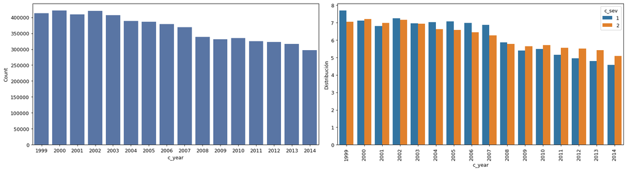

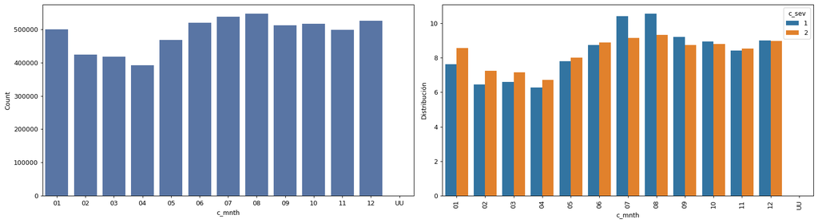

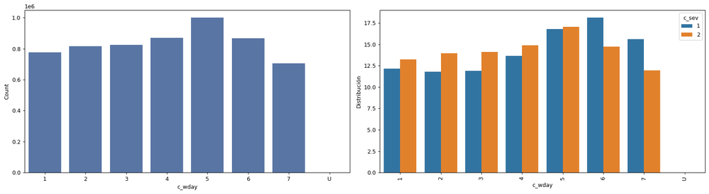

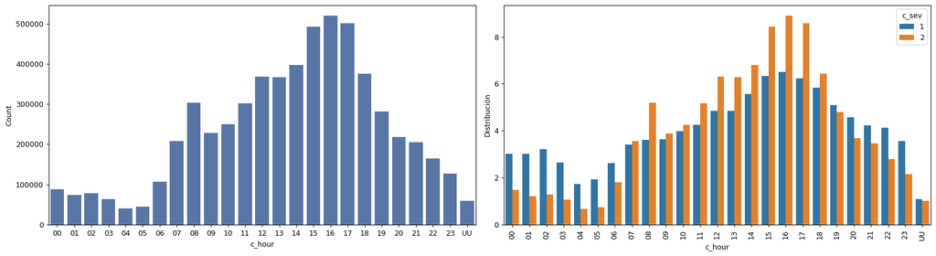

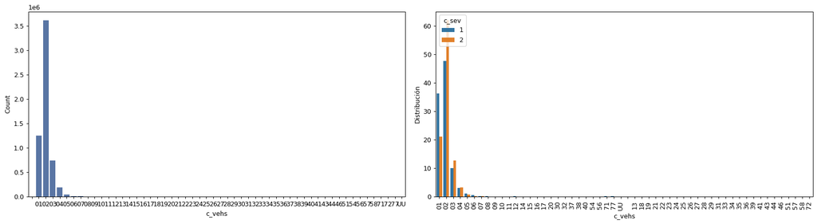

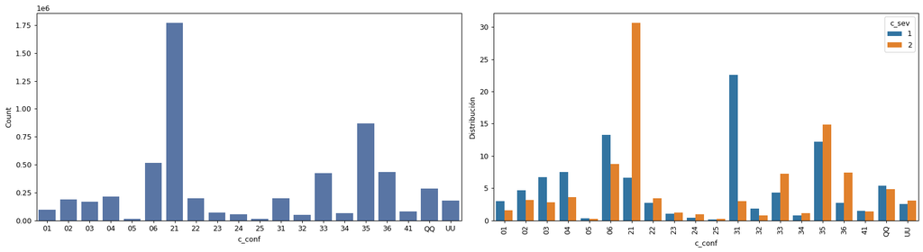

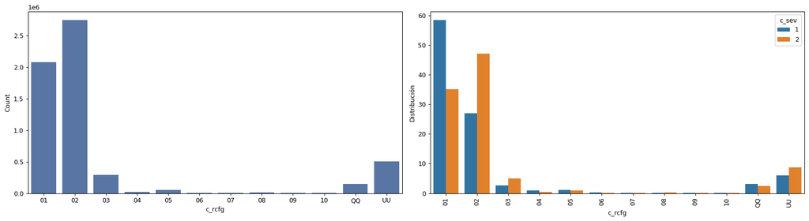

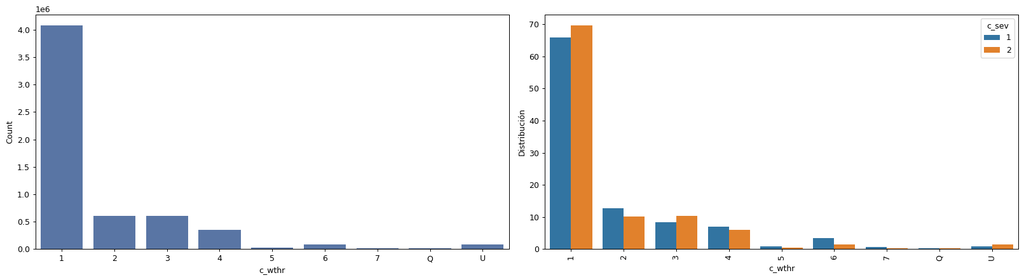

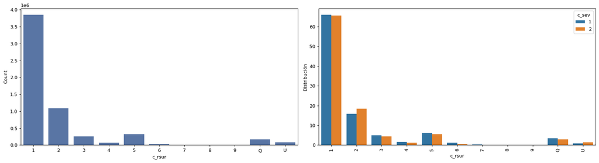

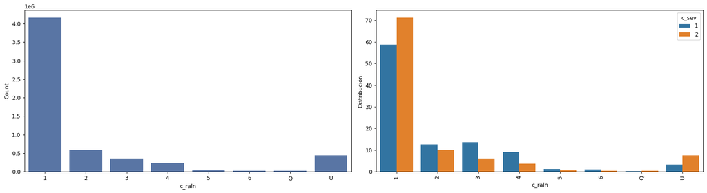

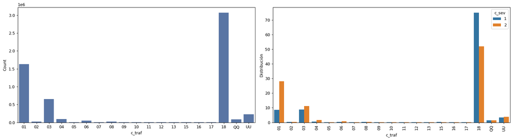

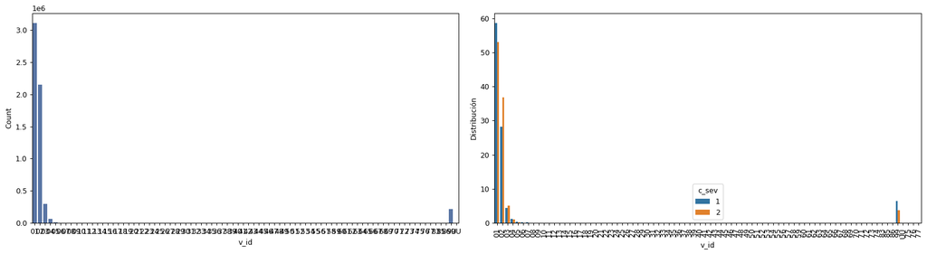

[9 more figures not shown]

```python
for i in df_acc.columns:
    if i != "c_sev":
        plot_feature(df_acc,i,"c_sev")
```

#### ANALIZAMOS LA DISTRIBUCIÓN DE LA VARIABLE OBJETIVO. (C_SEV)

```
Accidentes de trafico sin mortalidad: 5761772 ,Porcentaje %: 98.32
Accidentes de trafico con mortalidad: 98633 ,Porcentaje %: 1.68
```

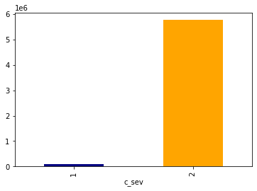

```python
df_csev = df_acc_p.groupby("c_sev").size()
df_csev.plot(kind="bar", color=["navy", "orange"])
print("Accidentes de trafico sin mortalidad:", df_csev[2], ",Porcentaje %:", (round(df_csev[2]/(df_csev[1]+df_csev[2])*100,2)))
print("Accidentes de trafico con mortalidad:", df_csev[1], ",Porcentaje %:", (round(df_csev[1]/(df_csev[1]+df_csev[2])*100,2)))
```

**Existe una gran diferencia entre la mortalidad(1) y la no mortalidad(2). Tenemos que equilibrar el dataset realizando un downsampling**

Examinando el Dataset, hemos visto que, la variable c_sev indica si hay o no hay muertos en un accidente, sin embargo, el dataset esta configurado de tal manera que, cada accidente pueden ser mas de una linea. Por ejemplo, si dos coches con un conductor en cada vehiculo tienen un accidente, el conductor del coche A muere pero el conductor del coche B no, en el dataset nos encontraremos dos lineas, una para el coche A, donde c_sev sera 1 (muerte), y otra para el coche B, donde c_sev tambien sera 1 (muerte). Esto genera una duplicidad de los datos de muertos, que nos puede generar ruido en nuestro modelo. De cara a simplificar las cosas vamos a agrupar por accidente.

#### ANALISIS CORRELACCIÓN VARIABLES CONTINUAS

Antes de realizar el análisis de correlacción, vamos a tratar alguna de estas variables, las cuales, tienen valores NA:

```python
df_acc_p.c_vehs = df_acc_p.c_vehs.replace("UU",99)
df_acc_p.c_vehs = df_acc_p.c_vehs.replace("",99)
df_acc_p.c_vehs = pd.to_numeric(df_acc_p.c_vehs)
df_acc_p.c_vehs
```

```
0           2
1           2
2           2
3           1
4           1
           ..
5860400    99
5860401     1
5860402     1
5860403     1
5860404     1
Name: c_vehs, Length: 5860405, dtype: int64
```

**V_YEAR:** Viendo la disposición de los años de los coches, creo que lo mas conveniente es introducir una media a los valores "NNNN" y "UUUU" a sabiendas que los "NNNN" son peatones y no coches. Esto nos puede suponer un gran problema, pero puede dar lugar a una nueva variable. Peaton y vehiculo. Seguiremos viendo como tratarlo.

```python
df_acc_p.v_year = df_acc_p.v_year.replace("NNNN",np.nan)
df_acc_p.v_year = df_acc_p.v_year.replace("UUUU",np.nan)
df_acc_p.v_year = pd.to_numeric(df_acc_p.v_year)
df_acc_p.v_year = df_acc_p.v_year.replace(np.nan, np.nanmean(df_acc_p.v_year)).astype(int)
df_acc_p.v_year
```

```
0          1990
1          1987
2          1987
3          1986
4          1998
           ...
5860400    1998
5860401    2006
5860402    2006
5860403    1998
5860404    1998
Name: v_year, Length: 5860405, dtype: int32
```

**P_AGE:** Rellenamos los NN y UU la media de la edad del dataframe.

```python
df_acc_p.p_age = df_acc_p.p_age.replace("NN",np.nan)
df_acc_p.p_age = df_acc_p.p_age.replace("UU",np.nan)
df_acc_p.p_age = pd.to_numeric(df_acc_p.p_age)
df_acc_p.p_age = df_acc_p.p_age.replace(np.nan, np.nanmean(df_acc_p.p_age)).astype(int)
df_acc_p.p_age
```

```
0          41
1          19
2          20
3          46
4           5
           ..
5860400    24
5860401    29
5860402    36
5860403    67
5860404    10
Name: p_age, Length: 5860405, dtype: int32
```

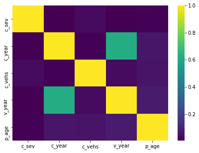

```python
corr = df_acc_p[["c_sev","c_year","c_vehs","v_year","p_age"]].corr(method = 'spearman')
plt.figure(figsize = (7, 5))
sns.heatmap(corr.abs(), cmap ='viridis' )
plt.show()
```

```python
corr = round(df_acc_p[variables_continuas].corr(),3)
corr.style.background_gradient()
```

|  | c_sev | c_year | c_vehs | v_year | p_age |
| --- | --- | --- | --- | --- | --- |
| c_sev | 1.000000 | 0.006000 | -0.015000 | 0.009000 | -0.015000 |
| c_year | 0.006000 | 1.000000 | 0.002000 | 0.603000 | 0.061000 |
| c_vehs | -0.015000 | 0.002000 | 1.000000 | 0.027000 | 0.021000 |
| v_year | 0.009000 | 0.603000 | 0.027000 | 1.000000 | 0.062000 |
| p_age | -0.015000 | 0.061000 | 0.021000 | 0.062000 | 1.000000 |

Vemos como el año de los coches con el año de colision tiene mucha relacción por lo que no podemos introducir las dos. Sin embargo, tal y como hemos comentado en las lineas anteriores, el dataset necesita una agrupación por accidente. Por lo que la linea v_year quedará totalmente descartada y nos quedaremos con `c_year`.

#### PEQUEÓ ANALISIS VARIABLES CONTINUAS:

```python
df_acc_p[variables_continuas].describe().apply(lambda s: s.apply(lambda x: format(x, 'g')))
```

|  | c_sev | c_year | c_vehs | v_year | p_age |
| --- | --- | --- | --- | --- | --- |
| count | 5.8604e+06 | 5.8604e+06 | 5.8604e+06 | 5.8604e+06 | 5.8604e+06 |
| mean | 1.98317 | 2006 | 2.05477 | 1998.46 | 36.3721 |
| std | 0.128636 | 4.56989 | 1.57549 | 6.76379 | 17.7394 |
| min | 1 | 1999 | 1 | 1901 | 1 |
| 25% | 2 | 2002 | 2 | 1994 | 22 |
| 50% | 2 | 2006 | 2 | 1998 | 36 |
| 75% | 2 | 2010 | 2 | 2003 | 48 |
| max | 2 | 2014 | 99 | 2015 | 99 |

En el describe de las variables continuas vemos algo que no es normal. El maximo de años de colisión es inferior al maximo de año de los vehiculos. Habra que eliminar las filas de los vehiculos que tengan mayor edad que la colisión, ya que son datos anormales.

# CONCLUSIONES:

Respecto al analisis de cada una de las variables:

- Vemos distribuciones muy distintas unas de otras. Diferenciamos entre las variables continuas, que son la minoria y cuya distribución suele ser o uniforme o bien determinadas por un gran numero de outliers. Para las distribuciones uniformes, y, de cara al preprocesamiento de datos, tendremos que utilizar o bien el standar scales para las uniformes o bien el robust scales para las que tienen demasiados valores atipicos.

Respecto al analisis valores extraños (Q,QQ,N,NN,U,UU,X,XX):

- No hay X ni XX.
- Como la mayoria de las variables son categoricas, los datos Na nos pueden aportar mucho valor, por lo que en la mayoria de los casos pretendemos quedarnos con ellos. Sin embargo, en algunas variables continuas si que haremos tratamiento de estos NA en función de la media o mediana, viendo en cada una su distribución.

Respecto al analisis de la variable objetivo `C_Sev:`

- Hay un desequilibrio en el dataset brutal. Por lo que tendremos que ver que tratamiento de datos le damos, propondremos varias soluciones.

Respecto al analisis de la correlacción de las variables continuas:

- Vemos una correlacción bastante fuerte entre los años y el año de los vehiculos algo que parece logico pero que nos puede dar problemas,

Respecto al dataset general:

- Hemos observado que el dataset esta organizado en función de las personas que sufren el accidente. Es decir, de este modo el accidente estará compuesto de varias lineas que son las personas que han tenido el accidente. Tenemos que agrupar el dataset por accidente.

Continuamos la prueba con nuestros 3 análisis EDA:

[1.1. Análisis de severidad.](http://localhost:8888/notebooks/Desktop/CUNEF/Practica%20Machine%20Learning/project_template/notebooks/1.1.analisis_EDA_Severidad.ipynb) Este análisis lo hacemos sin agrupar accidentes, pues queremos ver, en cada condición y con todas las variables que puede suceder en un accidente. Este análisis nos servirá tanto para nuestro primer objetivo que es averiguar si un accidente tiene mortalidad o no.

[1.2. Análisis de hospitalización.](http://localhost:8888/notebooks/Desktop/CUNEF/Practica%20Machine%20Learning/project_template/notebooks/1.2.analisis_EDA_Tratamiento_Medico.ipynb) Este análisis lo hacemos para ver las repercusiones totales que puede tener un accidente, no solo la mortalidad. Nos ayudará de cara a resolver nuestro segundo objetivo, predecir las hospitalizaciones de un accidente.

[1.3. Análisis de severidad Dataset Agrupado.](http://localhost:8888/notebooks/Desktop/CUNEF/Practica%20Machine%20Learning/project_template/notebooks/1.3.analisis_EDA_Agrupado_Severidad.%20.ipynb) Como hemos determinado que lo mejor para la predicción es agrupar el dataset por accidentes, vamos a realizar un análisis de la severidad con el dataset agrupado, se comparará con el `análisis 1.1.severidad`.